# Size Ret

FIN 4210

## Header File

```r
setwd("C:/Users/siche/Documents/teaching/Introduction to Financial Data Analysis/L6")
require(dplyr)
```

## Load the A Shares stock monthly return, market cap data from “a.shares.RData”

```r
load("a.shares.RData")
head(a.shares)
```

```
## # A tibble: 6 x 6
##   stock.id  yymm      mcap     ret      rf      mkt
##   <chr>    <dbl>     <dbl>   <dbl>   <dbl>    <dbl>
## 1 000001   2005  11791682. -0.0804 0.00186 -0.0575
## 2 000001   2005. 12608928.  0.0693 0.00186  0.0953
## 3 000001   2005. 10137733. -0.196  0.00186 -0.105
## 4 000001   2005. 12064097.  0.190  0.00186 -0.0365
## 5 000001   2005. 11694391. -0.0306 0.00186 -0.0697
## 6 000001   2005. 11538725. -0.0133 0.00186  0.00936
```

```r
size.ret = a.shares %>% select(stock.id,yymm,mcap,ret,mkt)
size.ret = size.ret %>% mutate(ret.mkt = ret-mkt)
head(size.ret)
```

```
## # A tibble: 6 x 6
##   stock.id  yymm      mcap     ret      mkt ret.mkt
##   <chr>    <dbl>     <dbl>   <dbl>    <dbl>   <dbl>
## 1 000001   2005  11791682. -0.0804 -0.0575  -0.0229
## 2 000001   2005. 12608928.  0.0693  0.0953  -0.0260
## 3 000001   2005. 10137733. -0.196  -0.105   -0.0905
## 4 000001   2005. 12064097.  0.190  -0.0365   0.226
## 5 000001   2005. 11694391. -0.0306 -0.0697   0.0390
## 6 000001   2005. 11538725. -0.0133  0.00936 -0.0227
```

```r
class(size.ret)
```

```
## [1] "tbl_df"     "tbl"        "data.frame"
```

## Step 1. Break Points

#### Create two columns that are list data type, one records the quantile number, the other are the quantiles

#### Use unnest from tidyr to unlist the list columns into a regular dataframe

```r
p = c(0.1,0.2,0.4,0.6,0.8,0.9)
library(tidyr)
bp = size.ret %>% group_by(yymm) %>%
  summarise(qt = list(paste0(p*100,"%")),
            break.point = list(quantile(mcap, p, type=3)))
head(bp)
```

```
## # A tibble: 6 x 3
##    yymm qt        break.point
##   <dbl> <list>    <list>
## 1 2005  <chr [6]> <dbl [6]>
## 2 2005. <chr [6]> <dbl [6]>
## 3 2005. <chr [6]> <dbl [6]>
## 4 2005. <chr [6]> <dbl [6]>
## 5 2005. <chr [6]> <dbl [6]>
## 6 2005. <chr [6]> <dbl [6]>
```

```r
bp = bp %>% unnest(cols=c(qt,break.point)) %>% ungroup()
head(bp)
```

```
## # A tibble: 6 x 3
##    yymm qt    break.point
##   <dbl> <chr>       <dbl>
## 1  2005 10%       539916.
## 2  2005 20%       676862.
## 3  2005 40%      1017261
## 4  2005 60%      1473165.
## 5  2005 80%      2487439.
## 6  2005 90%      4318304.
```

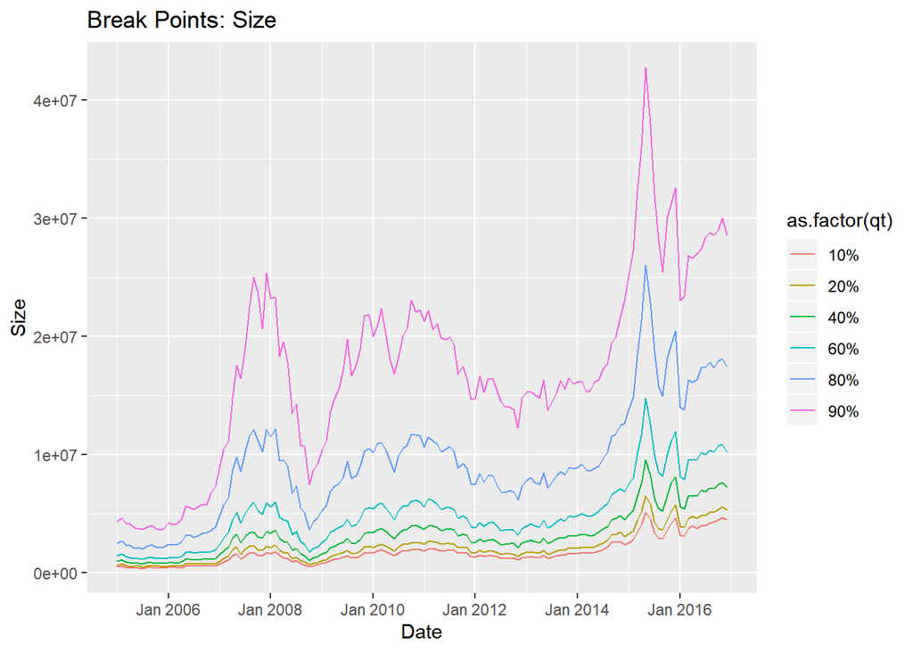

```r
library(ggplot2)
library(zoo)
ggplot(data=bp,
       aes(x=as.yearmon(yymm),
           y=break.point,
           col=as.factor(qt))) +
  scale_x_yearmon()+
  geom_line() +
  labs(title="Break Points: Size",
       y="Size",
       x="Date")
```

#### This plot helps us detech possible data issues. For market cap, it is natural the value increases over time. For some other data, it might be stable.

#### Spread the bp to better view the table

```r
bp = spread(bp,"qt","break.point")
head(bp)
```

```
## # A tibble: 6 x 7
##   yymm        `10%`   `20%`    `40%`    `60%`    `80%`    `90%`
##   <yearmon>   <dbl>   <dbl>    <dbl>    <dbl>    <dbl>    <dbl>
## 1 Jan 2005  539916. 676862. 1017261  1473165. 2487439. 4318304.
## 2 Feb 2005  600389. 753446. 1115652. 1619250  2732069. 4673760
## 3 Mar 2005  506647. 648941.  971732. 1398320  2387053. 4221720
## 4 Apr 2005  446633. 566100   875858. 1296407. 2306404. 4132500
## 5 May 2005  452733. 578302.  850532. 1250670  2120147. 3815000
## 6 Jun 2005  443274. 574133.  857169. 1245435. 2126339. 3732300
```

## Step 2. Group the entities in the sample into portfolios.

#### cut(v,breaks) function from base divides the range of a vector into intervals and codes the values in x according to which interval they fall. The leftmost interval corresponds to level one, the next leftmost to level two and so on.

#### breaks should always include the min and max of v if targeting at put all variables into labeled categories.

#### results are factor data type.

#### include.lowest = T to include the smallest values into the lowest category.

#### right = T, to indicate the intervals should be closed on the right (and open on the left) or vice versa.

#### ordered_results: logical on whether the result should ba an ordered factor

#### labels, gives names to categories

```r
v = seq(1,10)
cut(v,breaks = c(1,3,5,10),
    include.lowest = T)
```

```
##  [1] [1,3]  [1,3]  [1,3]  (3,5]  (3,5]  (5,10] (5,10] (5,10] (5,10] (5,10]
## Levels: [1,3] (3,5] (5,10]
```

```r
cut(v,breaks = c(3,1,5,10),
    include.lowest = T,
    ordered_result = T)
```

```
##  [1] [1,3]  [1,3]  [1,3]  (3,5]  (3,5]  (5,10] (5,10] (5,10] (5,10] (5,10]
## Levels: [1,3] < (3,5] < (5,10]
```

```r
cut(v,breaks = c(1,3,5,10),
    include.lowest = T,
    labels = c("1-3","3-5","5-10"))
```

```
##  [1] 1-3  1-3  1-3  3-5  3-5  5-10 5-10 5-10 5-10 5-10
## Levels: 1-3 3-5 5-10
```

#### Cut the size into portfolio based on the break points

#### We use quantile and cut together to form portfolios in one go

#### Take the first month data as an example

```r
eg = size.ret %>% filter(yymm==first(yymm))
head(eg)
```

```
## # A tibble: 6 x 6
##   stock.id yymm           mcap     ret     mkt ret.mkt
##   <chr>    <yearmon>     <dbl>   <dbl>   <dbl>   <dbl>
## 1 000001   Jan 2005  11791682. -0.0804 -0.0575 -0.0229
## 2 000002   Jan 2005  10839499.  0.0798 -0.0575  0.137
## 3 000004   Jan 2005    492943. -0.138  -0.0575 -0.0805
## 4 000005   Jan 2005   1488189. -0.0455 -0.0575  0.0121
## 5 000006   Jan 2005   1125947.  0.0751 -0.0575  0.133
## 6 000007   Jan 2005    538476.  0.109  -0.0575  0.167
```

```r
mybreaks = quantile(eg$mcap,p,type=3)
mymin = min(eg$mcap)
mymax = max(eg$mcap)
mymin; mymax; mybreaks
```

```
## [1] 120797.9
```

```
## [1] 279687804
```

```
##       10%       20%       40%       60%       80%       90%
##  539915.6  676861.7 1017261.0 1473165.3 2487439.3 4318304.4
```

```r
mybreaks = c(mymin,mybreaks,mymax)
mybreaks
```

```
##                     10%         20%         40%         60%         80%
##    120797.9    539915.6    676861.7   1017261.0   1473165.3   2487439.3
##         90%
##   4318304.4 279687804.0
```

```r
eg$port = cut(eg$mcap, breaks = mybreaks,
              include.lowest = T,
              ordered_result = T,
    labels = seq(1,7))
head(eg)
```

```
## # A tibble: 6 x 7
##   stock.id yymm           mcap     ret     mkt ret.mkt port
##   <chr>    <yearmon>     <dbl>   <dbl>   <dbl>   <dbl> <ord>
## 1 000001   Jan 2005  11791682. -0.0804 -0.0575 -0.0229 7
## 2 000002   Jan 2005  10839499.  0.0798 -0.0575  0.137  7
## 3 000004   Jan 2005    492943. -0.138  -0.0575 -0.0805 1
## 4 000005   Jan 2005   1488189. -0.0455 -0.0575  0.0121 5
## 5 000006   Jan 2005   1125947.  0.0751 -0.0575  0.133  4
## 6 000007   Jan 2005    538476.  0.109  -0.0575  0.167  1
```

#### Group by month and repeat the above steps for each month, the largest companies are labeled as “1”, while the smallest companies are labeled as “7”.

```r
port = size.ret %>% group_by(yymm) %>%
  mutate(size.port =
           cut(mcap,breaks = c(min(mcap),
                               quantile(mcap,p,type=3),
                               max(mcap)),
               include.lowest = T,
               ordered_result = T,
               labels=seq(7,1))) %>%
  ungroup()
head(port)
```

```
## # A tibble: 6 x 7
##   stock.id yymm           mcap     ret      mkt ret.mkt size.port
##   <chr>    <yearmon>     <dbl>   <dbl>    <dbl>   <dbl> <ord>
## 1 000001   Jan 2005  11791682. -0.0804 -0.0575  -0.0229 1
## 2 000001   Feb 2005  12608928.  0.0693  0.0953  -0.0260 1
## 3 000001   Mar 2005  10137733. -0.196  -0.105   -0.0905 1
## 4 000001   Apr 2005  12064097.  0.190  -0.0365   0.226  1
## 5 000001   May 2005  11694391. -0.0306 -0.0697   0.0390 1
## 6 000001   Jun 2005  11538725. -0.0133  0.00936 -0.0227 1
```

```r
tail(port)
```

```
## # A tibble: 6 x 7
##   stock.id yymm          mcap     ret     mkt ret.mkt size.port
##   <chr>    <yearmon>    <dbl>   <dbl>   <dbl>   <dbl> <ord>
## 1 603999   Jul 2016   8723520 -0.0207  0.0182 -0.0389 4
## 2 603999   Aug 2016   8864640  0.0162  0.0357 -0.0195 4
## 3 603999   Sep 2016   9466560  0.0679 -0.0197  0.0876 4
## 4 603999   Oct 2016  11102400  0.173   0.0334  0.139  3
## 5 603999   Nov 2016  10157760 -0.0851  0.0386 -0.124  4
## 6 603999   Dec 2016   8444160 -0.169  -0.0443 -0.124  4
```

#### Summarise the number of stocks

#### First count the total number of stocks each month

```r
n.port = port %>% group_by(yymm) %>%
  mutate(n.total=n()) %>% ungroup()
head(n.port)
```

```
## # A tibble: 6 x 8
##   stock.id yymm           mcap     ret      mkt ret.mkt size.port n.total
##   <chr>    <yearmon>     <dbl>   <dbl>    <dbl>   <dbl> <ord>       <int>
## 1 000001   Jan 2005  11791682. -0.0804 -0.0575  -0.0229 1            1309
## 2 000001   Feb 2005  12608928.  0.0693  0.0953  -0.0260 1            1329
## 3 000001   Mar 2005  10137733. -0.196  -0.105   -0.0905 1            1342
## 4 000001   Apr 2005  12064097.  0.190  -0.0365   0.226  1            1347
## 5 000001   May 2005  11694391. -0.0306 -0.0697   0.0390 1            1328
## 6 000001   Jun 2005  11538725. -0.0133  0.00936 -0.0227 1            1330
```

#### Count the number of stocks in each portfolio over time

```r
n.port = n.port %>% group_by(yymm,size.port) %>%
  summarise(n.total = first(n.total),
            n = n()) %>% ungroup()
head(n.port)
```

```
## # A tibble: 6 x 4
##   yymm      size.port n.total     n
##   <yearmon> <ord>       <int> <int>
## 1 Jan 2005  7            1309   131
## 2 Jan 2005  6            1309   131
## 3 Jan 2005  5            1309   262
## 4 Jan 2005  4            1309   261
## 5 Jan 2005  3            1309   262
## 6 Jan 2005  2            1309   131
```

```r
n.port.wide = n.port %>% spread("size.port","n")
head(n.port.wide)
```

```
## # A tibble: 6 x 9
##   yymm      n.total   `7`   `6`   `5`   `4`   `3`   `2`   `1`
##   <yearmon>   <int> <int> <int> <int> <int> <int> <int> <int>
## 1 Jan 2005     1309   131   131   262   261   262   131   131
## 2 Feb 2005     1329   133   133   266   265   266   133   133
## 3 Mar 2005     1342   134   134   269   268   269   134   134
## 4 Apr 2005     1347   135   134   270   269   270   134   135
## 5 May 2005     1328   133   133   265   266   265   133   133
## 6 Jun 2005     1330   133   133   266   266   266   133   133
```

#### Visualise the size of each portfolio

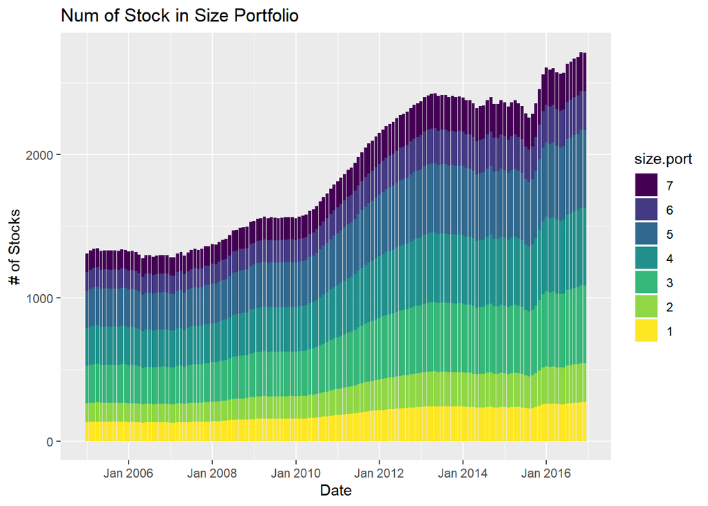

```r
ggplot(data = n.port, aes(y=n, x=as.yearmon(yymm), fill=size.port)) +
  geom_bar(stat="identity") + scale_x_yearmon() +
  labs(x='Date',
       y='# of Stocks',
       title='Num of Stock in Size Portfolio')
```

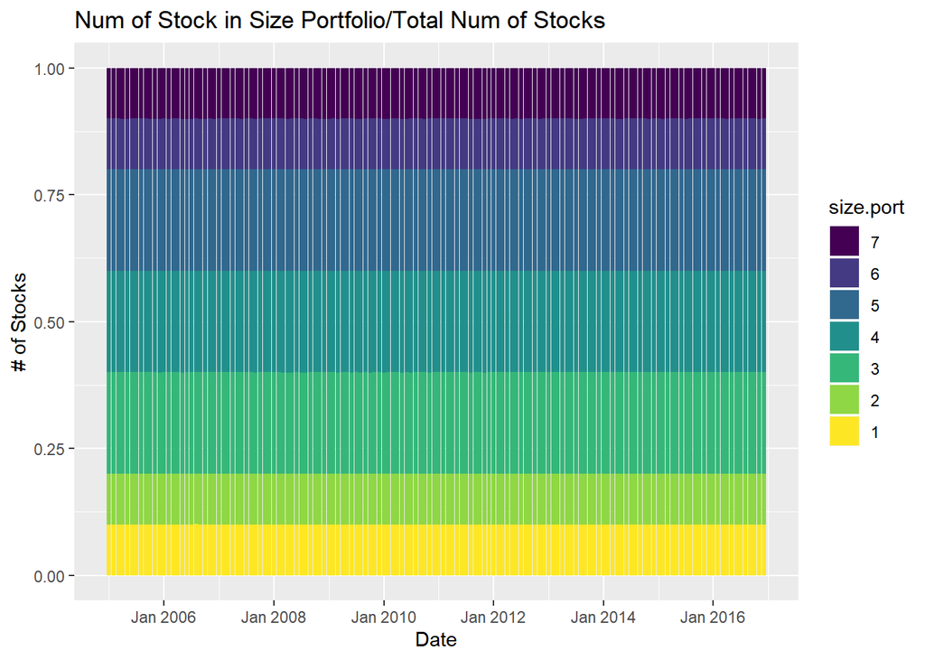

```r
ggplot(data = n.port, aes(y=n/n.total, x=as.yearmon(yymm), fill=size.port)) +
  geom_bar(stat="identity") + scale_x_yearmon() +
  labs(x='Date',
       y='# of Stocks',
       title='Num of Stock in Size Portfolio/Total Num of Stocks')
```

## Step 3. Average Portfolio Values

#### Some stocks might stop trading for some months, thus using dplyr group_by and lead returns might not be accurate.

#### Use spread to handle the missing returns

```r
ret.m = size.ret %>% select(stock.id,yymm,ret.mkt)
ret.m = spread(ret.m,"stock.id","ret.mkt")
ret.m = gather(ret.m,key = "stock.id",value='ret.mkt', -yymm)
head(ret.m,10)
```

```
## # A tibble: 10 x 3
##    yymm      stock.id ret.mkt
##    <yearmon> <chr>      <dbl>
##  1 Jan 2005  000001   -0.0229
##  2 Feb 2005  000001   -0.0260
##  3 Mar 2005  000001   -0.0905
##  4 Apr 2005  000001    0.226
##  5 May 2005  000001    0.0390
##  6 Jun 2005  000001   -0.0227
##  7 Jul 2005  000001    0.0200
##  8 Aug 2005  000001   -0.0396
##  9 Sep 2005  000001   -0.0823
## 10 Oct 2005  000001    0.0449
```

```r
ret.m = ret.m %>% group_by(stock.id) %>% arrange(yymm) %>%
  mutate(ret.mkt.lead.m1 = dplyr::lead(ret.mkt,1)) %>%
  ungroup() %>% arrange(stock.id,yymm)
head(ret.m)
```

```
## # A tibble: 6 x 4
##   yymm      stock.id ret.mkt ret.mkt.lead.m1
##   <yearmon> <chr>      <dbl>           <dbl>
## 1 Jan 2005  000001   -0.0229         -0.0260
## 2 Feb 2005  000001   -0.0260         -0.0905
## 3 Mar 2005  000001   -0.0905          0.226
## 4 Apr 2005  000001    0.226           0.0390
## 5 May 2005  000001    0.0390         -0.0227
## 6 Jun 2005  000001   -0.0227          0.0200
```

```r
ret.m = ret.m %>% select(yymm,stock.id,ret.mkt.lead.m1) %>%
  na.omit()
```

#### Merge the lead returns to the categorize size portfolio

#### Use inner_join as require no missing value in both the mcap and lead returns.

```r
port = port %>% inner_join(ret.m,by=c("stock.id","yymm"))
head(port)
```

```
## # A tibble: 6 x 8
##   stock.id yymm     mcap     ret      mkt ret.mkt size.port ret.mkt.lead.m1
##   <chr>    <year>  <dbl>   <dbl>    <dbl>   <dbl> <ord>               <dbl>
## 1 000001   Jan 2~ 1.18e7 -0.0804 -0.0575  -0.0229 1                 -0.0260
## 2 000001   Feb 2~ 1.26e7  0.0693  0.0953  -0.0260 1                 -0.0905
## 3 000001   Mar 2~ 1.01e7 -0.196  -0.105   -0.0905 1                  0.226
## 4 000001   Apr 2~ 1.21e7  0.190  -0.0365   0.226  1                  0.0390
## 5 000001   May 2~ 1.17e7 -0.0306 -0.0697   0.0390 1                 -0.0227
## 6 000001   Jun 2~ 1.15e7 -0.0133  0.00936 -0.0227 1                  0.0200
```

#### Calculate each portfolio’s lead returns next month

```r
port.ret = port %>% group_by(yymm,size.port) %>%
  summarise(ret.ew = mean(ret.mkt.lead.m1,na.rm=T)) %>%
  ungroup() %>% arrange(yymm,size.port)
```

#### Visualise the portfolio returns

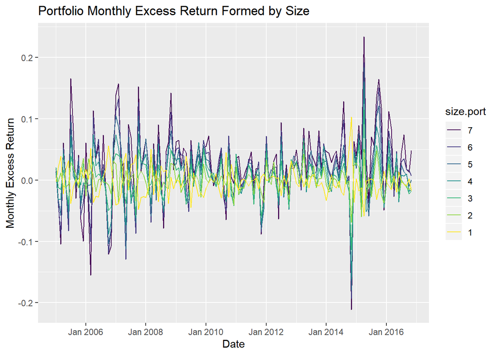

```r
ggplot(data=port.ret,
       aes(x=as.yearmon(yymm),
           y=ret.ew,
           col=size.port))+
  geom_line() +
  scale_x_yearmon() +
  labs(x="Date",y="Monthly Excess Return",
       title="Portfolio Monthly Excess Return Formed by Size")
```

#### Calculate the difference portfolio

```r
port.ret.wide = spread(port.ret,"size.port","ret.ew")
port.ret.wide$"7-1" = port.ret.wide$`7`-port.ret.wide$`1`
head(port.ret.wide)
```

```
## # A tibble: 6 x 9
##   yymm       `7`     `6`      `5`     `4`     `3`      `2`      `1`   `7-1`
##   <year>   <dbl>   <dbl>    <dbl>   <dbl>   <dbl>    <dbl>    <dbl>   <dbl>
## 1 Jan 2~  0.0179  0.0126  0.0129   0.0102  0.0202 -0.00149 -0.00236  0.0203
## 2 Feb 2~ -0.0305 -0.0375 -0.0311  -0.0312 -0.0116 -0.00209  0.0195  -0.0500
## 3 Mar 2~ -0.104  -0.0880 -0.0572  -0.0314 -0.0151  0.0117   0.0389  -0.143
## 4 Apr 2~  0.0607  0.0528  0.0493   0.0433  0.0169 -0.0112  -0.0225   0.0832
## 5 May 2~ -0.0113 -0.0113 -0.00851 -0.0117 -0.0134 -0.0109   0.0187  -0.0300
## 6 Jun 2~ -0.0796 -0.0830 -0.0622  -0.0508 -0.0388 -0.00681  0.0319  -0.111
```

```r
port.ret = gather(port.ret.wide,size.port,ret.ew,-yymm)
head(port.ret)
```

```
## # A tibble: 6 x 3
##   yymm      size.port  ret.ew
##   <yearmon> <chr>       <dbl>
## 1 Jan 2005  7          0.0179
## 2 Feb 2005  7         -0.0305
## 3 Mar 2005  7         -0.104
## 4 Apr 2005  7          0.0607
## 5 May 2005  7         -0.0113
## 6 Jun 2005  7         -0.0796
```

```r
tail(port.ret)
```

```
## # A tibble: 6 x 3
##   yymm      size.port  ret.ew
##   <yearmon> <chr>       <dbl>
## 1 Jun 2016  7-1       -0.0250
## 2 Jul 2016  7-1        0.0453
## 3 Aug 2016  7-1        0.0812
## 4 Sep 2016  7-1        0.0261
## 5 Oct 2016  7-1        0.0103
## 6 Nov 2016  7-1        0.0660
```

## Step 4. Examine the variation in these average values of Y across the different portfolios.

```r
summary.stat = port.ret %>% group_by(size.port) %>%
  summarise(average = mean(ret.ew),
            n = n(),
            standard.error = sd(ret.ew)/sqrt(n),
            t.stat = average/standard.error,
            p.value = 2*(1-pnorm(abs(t.stat))))

summary.stat
```

```
## # A tibble: 8 x 6
##   size.port   average     n standard.error  t.stat     p.value
##   <chr>         <dbl> <int>          <dbl>   <dbl>       <dbl>
## 1 1         -0.00176    143        0.00193 -0.914  0.361
## 2 2          0.000150   143        0.00167  0.0898 0.928
## 3 3          0.00323    143        0.00244  1.32   0.186
## 4 4          0.00741    143        0.00334  2.22   0.0265
## 5 5          0.0117     143        0.00392  2.98   0.00291
## 6 6          0.0170     143        0.00454  3.76   0.000173
## 7 7          0.0266     143        0.00531  5.01   0.000000544
## 8 7-1        0.0283     143        0.00687  4.12   0.0000371
```

#### Visualise the portfolio returns over time

```r
summary.stat
```

```
## # A tibble: 8 x 6
##   size.port   average     n standard.error  t.stat     p.value
##   <chr>         <dbl> <int>          <dbl>   <dbl>       <dbl>
## 1 1         -0.00176    143        0.00193 -0.914  0.361
## 2 2          0.000150   143        0.00167  0.0898 0.928
## 3 3          0.00323    143        0.00244  1.32   0.186
## 4 4          0.00741    143        0.00334  2.22   0.0265
## 5 5          0.0117     143        0.00392  2.98   0.00291
## 6 6          0.0170     143        0.00454  3.76   0.000173
## 7 7          0.0266     143        0.00531  5.01   0.000000544
## 8 7-1        0.0283     143        0.00687  4.12   0.0000371
```

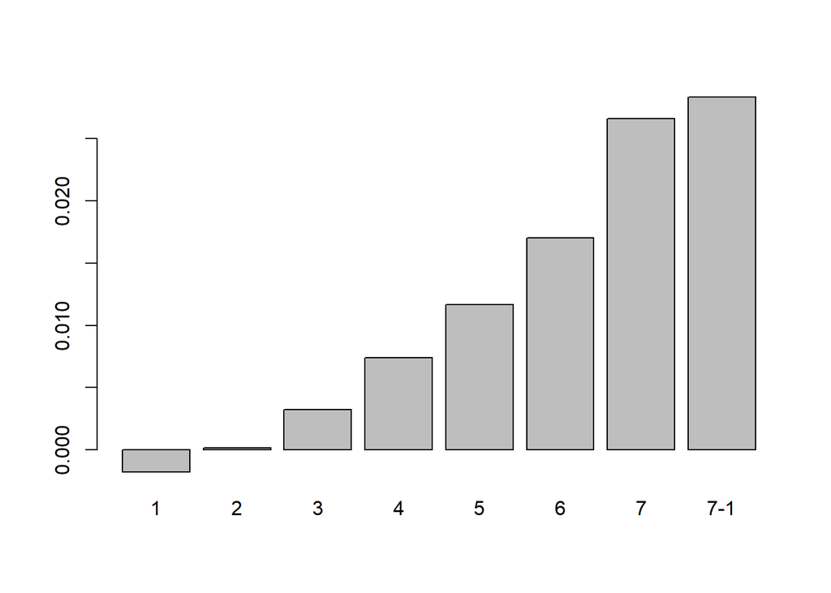

```r
with(summary.stat,
     barplot(average,names.arg = size.port))
```

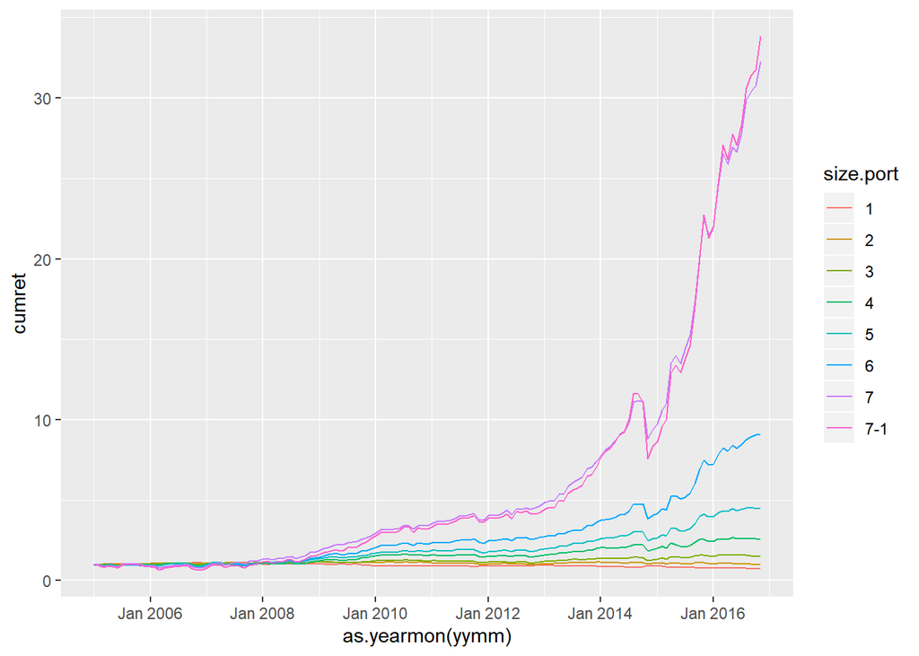

```r
port.ret = port.ret %>% group_by(size.port) %>% arrange(yymm) %>% mutate(cumret = cumprod(ret.ew+1)) %>% ungroup()


ggplot(data=port.ret,
       aes(x=as.yearmon(yymm),
           y=cumret,
           col=size.port))+
  geom_line() +
  scale_x_yearmon()
```